# Business Statistics End of Term Assessment IB94X0 2024-2025 #1

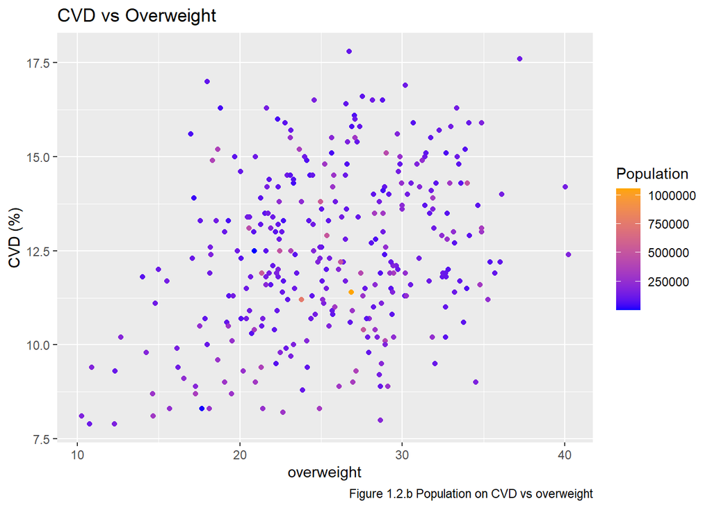

```r
ggplot(cvd, aes(x = overweight, y = CVD)) +
  geom_point(aes(color = Population)) +
  labs(title = "CVD vs Overweight", x = "overweight", y = "CVD (%)", caption = "Figure 1.2.b Population on CVD vs overweight")+
  scale_color_gradient(low = "blue", high = "orange")
```

[figure not shown]

```r
ggplot(cvd, aes(x = smokers, y = CVD)) +
  geom_point(aes(color = Population)) +
  labs(title = "CVD vs Smokers", x = "Smokers (%)", y = "CVD", caption = "Figure 1.2.c Population on CVD vs Overweight")+
  scale_color_gradient(low = "blue", high = "orange")
```

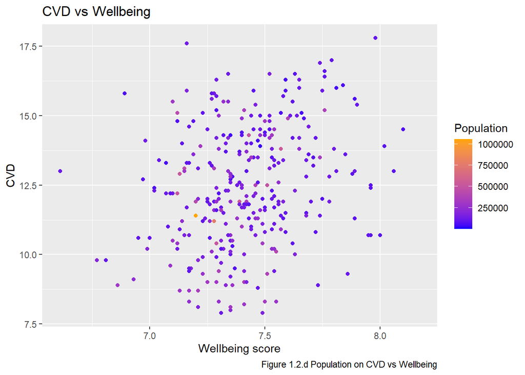

```r
ggplot(cvd, aes(x = wellbeing, y = CVD)) +
  geom_point(aes(color = Population)) +
  labs(title = "CVD vs Wellbeing", x = "Wellbeing score", y = "CVD", caption = "Figure 1.2.d Population on CVD vs Wellbeing")+
  scale_color_gradient(low = "blue", high = "orange")
```

Figure 1.2 shows that the values with high population is scattered around with no particular concentrated area. This indicates that the abnormally high population does not affect other predictors. With the data being a scaled data and the distribution is approximately normal, no data is removed.

## Linear Modelling

To identify how the percentage of poverty, overweight, smokers, and wellbeing score effects the prevalence of CVD in the area, linear modelling is performed.

### Without interaction

```r
m.cvd.all <- lm(CVD~ Poverty + overweight +smokers+wellbeing, data = cvd)
summary(m.cvd.all)
```

```
##
## Call:
## lm(formula = CVD ~ Poverty + overweight + smokers + wellbeing,
##     data = cvd)
##
## Residuals:
##     Min      1Q  Median      3Q     Max
## -4.3966 -1.4313 -0.1097  1.3905  4.7779
##
## Coefficients:
##             Estimate Std. Error t value Pr(>|t|)
## (Intercept) -1.69780    3.93361  -0.432 0.666335
## Poverty     -0.18400    0.03515  -5.234 3.13e-07 ***
## overweight   0.10985    0.02123   5.174 4.22e-07 ***
## smokers      0.12030    0.03366   3.574 0.000410 ***
## wellbeing    1.80025    0.49096   3.667 0.000291 ***
## ---
## Signif. codes:  0 '***' 0.001 '**' 0.01 '*' 0.05 '.' 0.1 ' ' 1
##
## Residual standard error: 1.894 on 298 degrees of freedom
##   (82 observations deleted due to missingness)
## Multiple R-squared:  0.2494, Adjusted R-squared:  0.2393
## F-statistic: 24.75 on 4 and 298 DF,  p-value: < 2.2e-16
```

Without interactions, CVD can be predicted with the model, CVD predict = -1.698 - 0.184 poverty + 0.110 overweight + 0.120 smokers + 1.800 wellbeing.

Interpretation of the coefficients:

1.Poverty: For each one percentage point increase in poverty, the CVD rate decreases by 0.184 percentage points, which is significantly different from zero (t(298) = -5.234, p < 0.001).

2.Overweight: For each one percentage point increase in the proportion of overweight individuals, the CVD rate increases by 0.110 percentage points, which is significantly different from zero (t(298) = 5.174, p < 0.001).

3.Smokers: For each one percentage point increase in the proportion of smokers, the CVD rate increases by 0.120 percentage points, which is significantly different from zero (t(298) = 3.574, p < 0.001).

4.Wellbeing: For each one point increase in the wellbeing score, the CVD rate increases by 1.800 percentage points, which is significantly different from zero (t(298) = 3.667, p < 0.001).

All predictors (poverty, overweight, smokers, and wellbeing) are significantly affecting CVD. The negative relationship between CVD and poverty suggest that area with higher poverty have lower CVD rates, while the positive relationship between CVD and overweight, smokers, and wellbeing suggest areas with higher percentage of those predictor have higher CVD rates.

#### Multicollinearity Evaluation

To check the accuracy and stability of the model, the multicollinearity of the variables are evaluated with Variance Inflation Factor (VIF).

```r
vif(m.cvd.all)
```

```
##    Poverty overweight    smokers  wellbeing
##   1.263094   1.196546   1.359206   1.145506
```

The low VIF result indicates low multicollinearity between the predictor variables. This means the variable does not share redundant information.

### Interaction Evaluation

To further evaluate the impact of each predictors to the prevalence of CVD, the interactions between the predictors and CVD is analysed.

```r
m.cvd.pov.ow.int.all <- lm(CVD~ Poverty * overweight + smokers + wellbeing, data = cvd)
summary(m.cvd.pov.ow.int.all)
```

```
##
## Call:
## lm(formula = CVD ~ Poverty * overweight + smokers + wellbeing,
##     data = cvd)
##
## Residuals:
##     Min      1Q  Median      3Q     Max
## -4.2566 -1.3920 -0.2149  1.3413  4.6777
##
## Coefficients:
##                     Estimate Std. Error t value Pr(>|t|)
## (Intercept)         6.044246   4.869750   1.241 0.215518
## Poverty            -0.533549   0.136509  -3.909 0.000115 ***
## overweight         -0.185687   0.113565  -1.635 0.103093
## smokers             0.110702   0.033525   3.302 0.001077 **
## wellbeing           1.721960   0.486983   3.536 0.000471 ***
## Poverty:overweight  0.014638   0.005528   2.648 0.008526 **
## ---
## Signif. codes:  0 '***' 0.001 '**' 0.01 '*' 0.05 '.' 0.1 ' ' 1
##
## Residual standard error: 1.875 on 297 degrees of freedom
##   (82 observations deleted due to missingness)
## Multiple R-squared:  0.2667, Adjusted R-squared:  0.2543
## F-statistic:  21.6 on 5 and 297 DF,  p-value: < 2.2e-16
```

```r
m.cvd.pov.wb.int <- lm(CVD~ Poverty * wellbeing + overweight + smokers, data = cvd)
summary(m.cvd.pov.wb.int)
```

```
##
## Call:
## lm(formula = CVD ~ Poverty * wellbeing + overweight + smokers,
##     data = cvd)
##
## Residuals:
##     Min      1Q  Median      3Q     Max
## -4.3939 -1.4073 -0.1073  1.3431  4.8171
##
## Coefficients:
##                    Estimate Std. Error t value Pr(>|t|)
## (Intercept)       -15.44579   20.86330  -0.740 0.459683
## Poverty             0.53620    1.07387   0.499 0.617930
## wellbeing           3.66240    2.81831   1.300 0.194779
## overweight          0.11268    0.02167   5.201 3.71e-07 ***
## smokers             0.11912    0.03374   3.530 0.000481 ***
## Poverty:wellbeing  -0.09814    0.14625  -0.671 0.502734
## ---
## Signif. codes:  0 '***' 0.001 '**' 0.01 '*' 0.05 '.' 0.1 ' ' 1
##
## Residual standard error: 1.895 on 297 degrees of freedom
##   (82 observations deleted due to missingness)
## Multiple R-squared:  0.2505, Adjusted R-squared:  0.2379
## F-statistic: 19.85 on 5 and 297 DF,  p-value: < 2.2e-16
```

```r
m.cvd.pov.smok.int <- lm(CVD~ Poverty * smokers + overweight + wellbeing, data = cvd)
summary(m.cvd.pov.smok.int)
```

```
##
## Call:
## lm(formula = CVD ~ Poverty * smokers + overweight + wellbeing,
##     data = cvd)
##
## Residuals:
##     Min      1Q  Median      3Q     Max
## -4.3621 -1.4209 -0.0744  1.3681  4.7773
##
## Coefficients:
##                  Estimate Std. Error t value Pr(>|t|)
## (Intercept)     -0.501573   4.369196  -0.115 0.908683
## Poverty         -0.253839   0.116016  -2.188 0.029450 *
## smokers          0.011500   0.175491   0.066 0.947796
## overweight       0.108874   0.021311   5.109 5.81e-07 ***
## wellbeing        1.823861   0.492880   3.700 0.000256 ***
## Poverty:smokers  0.005538   0.008766   0.632 0.528035
## ---
## Signif. codes:  0 '***' 0.001 '**' 0.01 '*' 0.05 '.' 0.1 ' ' 1
##
## Residual standard error: 1.896 on 297 degrees of freedom
##   (82 observations deleted due to missingness)
## Multiple R-squared:  0.2504, Adjusted R-squared:  0.2378
## F-statistic: 19.84 on 5 and 297 DF,  p-value: < 2.2e-16
```

```r
m.cvd.smok.ow.int <- lm(CVD~ smokers * overweight + Poverty + wellbeing, data = cvd)
summary(m.cvd.smok.ow.int)
```

```
##
## Call:
## lm(formula = CVD ~ smokers * overweight + Poverty + wellbeing,
##     data = cvd)
##
## Residuals:
##     Min      1Q  Median      3Q     Max
## -4.4367 -1.4470 -0.1023  1.3589  4.8961
##
## Coefficients:
##                     Estimate Std. Error t value Pr(>|t|)
## (Intercept)        -2.631443   4.205115  -0.626 0.531945
## smokers             0.207702   0.142215   1.460 0.145216
## overweight          0.153853   0.072733   2.115 0.035236 *
## Poverty            -0.182888   0.035232  -5.191 3.89e-07 ***
## wellbeing           1.774214   0.493180   3.597 0.000376 ***
## smokers:overweight -0.003391   0.005360  -0.633 0.527508
## ---
## Signif. codes:  0 '***' 0.001 '**' 0.01 '*' 0.05 '.' 0.1 ' ' 1
##
## Residual standard error: 1.896 on 297 degrees of freedom
##   (82 observations deleted due to missingness)
## Multiple R-squared:  0.2504, Adjusted R-squared:  0.2378
## F-statistic: 19.84 on 5 and 297 DF,  p-value: < 2.2e-16
```

```r
m.cvd.well.ow.int <- lm(CVD~ wellbeing * overweight + Poverty + smokers, data = cvd)
summary(m.cvd.well.ow.int)
```

```
##
## Call:
## lm(formula = CVD ~ wellbeing * overweight + Poverty + smokers,
##     data = cvd)
##
## Residuals:
##     Min      1Q  Median      3Q     Max
## -4.3616 -1.4439 -0.1281  1.4479  4.6546
##
## Coefficients:
##                       Estimate Std. Error t value Pr(>|t|)
## (Intercept)          -17.85558   16.34914  -1.092  0.27566
## wellbeing              3.98448    2.20064   1.811  0.07121 .
## overweight             0.76857    0.64729   1.187  0.23603
## Poverty               -0.17927    0.03546  -5.056  7.5e-07 ***
## smokers                0.11587    0.03394   3.414  0.00073 ***
## wellbeing:overweight  -0.08924    0.08765  -1.018  0.30941
## ---
## Signif. codes:  0 '***' 0.001 '**' 0.01 '*' 0.05 '.' 0.1 ' ' 1
##
## Residual standard error: 1.894 on 297 degrees of freedom
##   (82 observations deleted due to missingness)
## Multiple R-squared:  0.252,  Adjusted R-squared:  0.2394
## F-statistic: 20.01 on 5 and 297 DF,  p-value: < 2.2e-16
```

```r
m.cvd.well.smok.int <- lm(CVD~ wellbeing * smokers + Poverty + overweight, data = cvd)
summary(m.cvd.well.smok.int)
```

```
##
## Call:
## lm(formula = CVD ~ wellbeing * smokers + Poverty + overweight,
##     data = cvd)
##
## Residuals:
##     Min      1Q  Median      3Q     Max
## -4.4006 -1.4321 -0.0851  1.3933  4.7855
##
## Coefficients:
##                   Estimate Std. Error t value Pr(>|t|)
## (Intercept)       -0.62086   10.43620  -0.059    0.953
## wellbeing          1.65367    1.40420   1.178    0.240
## smokers            0.03111    0.80112   0.039    0.969
## Poverty           -0.18362    0.03537  -5.191 3.89e-07 ***
## overweight         0.11006    0.02135   5.156 4.63e-07 ***
## wellbeing:smokers  0.01202    0.10789   0.111    0.911
## ---
## Signif. codes:  0 '***' 0.001 '**' 0.01 '*' 0.05 '.' 0.1 ' ' 1
##
## Residual standard error: 1.897 on 297 degrees of freedom
##   (82 observations deleted due to missingness)
## Multiple R-squared:  0.2494, Adjusted R-squared:  0.2368
## F-statistic: 19.74 on 5 and 297 DF,  p-value: < 2.2e-16
```

Evaluating the possible model outcomes with interactions between the predictors using R-squared, the model that includies the interaction between poverty and overweight provides the best performance. To statistically compare between the model without overweight interaction with poverty and with interaction, ANOVA analysis is performed.

```r
anova(m.cvd.all, m.cvd.pov.ow.int.all)
```

```
## Analysis of Variance Table
##
## Model 1: CVD ~ Poverty + overweight + smokers + wellbeing
## Model 2: CVD ~ Poverty * overweight + smokers + wellbeing
##   Res.Df    RSS Df Sum of Sq      F   Pr(>F)
## 1    298 1068.6
## 2    297 1043.9  1    24.649 7.0127 0.008526 **
## ---
## Signif. codes:  0 '***' 0.001 '**' 0.01 '*' 0.05 '.' 0.1 ' ' 1
```

The ANOVA results shows that the model with interaction provides a significantly better fit than the model without interaction (p(297)= 7.0127, Pr <0.05). Therefore, the interaction between poverty and overweight is an important factor in CVD modelling.

From the model, CVD can be predicted as CVD predict = 6.044 - 0.534 poverty - 0.186 overweight + 0.111 smokers + 1.722 wellbeing + 0.015 poverty x overweight.

Interpretation of the coefficients:

1.Poverty: For each one percentage point increase in poverty, the CVD rate decreases by 0.534 percentage points, which is significantly different from zero (t(297) = -3.909, p < 0.001).

2.Overweight: For each one percentage point increase in the proportion of overweight individuals, the CVD rate decreases by 0.186 percentage points, which is not significantly different from zero (t(297) = -1.635, p = 0.103).

3.Smokers: For each one percentage point increase in the proportion of smokers, the CVD rate increases by 0.111 percentage points, which is significantly different from zero (t(297) = 3.302, p < 0.01).

4.Wellbeing: For each one point increase in the wellbeing score, the CVD rate increases by 1.722 percentage points, which is significantly different from zero (t(297) = 3.536, p < 0.01).

5.Poverty x overweight: For each one point increase in the poverty:overweight score, the CVD rate increases by 0.015 percentage points, which is significantly different from zero (t(297) = 2.648, p < 0.01).

Predictors such as poverty, smokers, wellbeing, and the interaction between poverty and overweight are significantly affecting CVD. The negative relationship between CVD and poverty suggest that area with higher poverty have lower CVD rates, while the positive relationship between CVD and smokers, and wellbeing suggest areas with higher percentage of those predictor have higher CVD rates. The interaction between poverty and overweight also has a positive relationship to CVD.

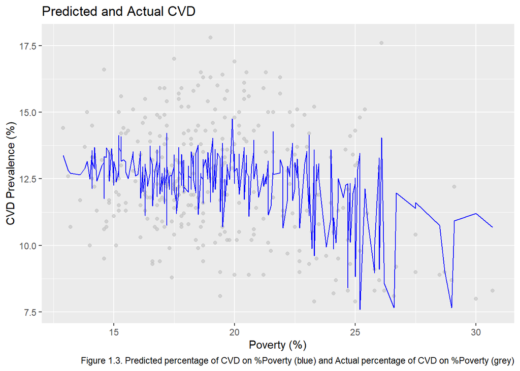

```r
cvdpred <- na.omit(cvd) #removing Na values in cvd dataset to prepare it for the model

cvdpred$cvdhat <- predict(m.cvd.pov.ow.int.all, cvdpred) #using the cvd as input for the model

ggplot(cvdpred, aes(x = Poverty)) +
  geom_point(aes(y = CVD), alpha = 0.6, color = "grey") +
  geom_line(aes(y = cvdhat), color = "blue") +
  labs(
    title = "Predicted and Actual CVD",
    x = "Poverty (%)",
    y = "CVD Prevalence (%)",
    caption = "Figure 1.3. Predicted percentage of CVD on %Poverty (blue) and Actual percentage of CVD on %Poverty (grey)"
  )
```

```r
# creating a tibble of mean values for prediction
predict2 <- tibble(
  Poverty = seq(min(cvdpred$Poverty), max(cvdpred$Poverty), length.out = 100),
  overweight = mean(cvdpred$overweight, na.rm = TRUE),
  smokers = mean(cvdpred$smokers, na.rm = TRUE),
  wellbeing = mean(cvdpred$wellbeing, na.rm = TRUE)
)

predict2$cvdhat2 <- predict(m.cvd.pov.ow.int.all, predict2)

mean_table <- cvdpred %>%
  summarise(
    overweight = mean(overweight, na.rm = TRUE),
    smokers = mean(smokers, na.rm = TRUE),
    wellbeing = mean(wellbeing, na.rm = TRUE)
  )
mean_table%>% kable(format="pipe")
```

| overweight | smokers | wellbeing |
| --- | --- | --- |
| 25.54437 | 12.86568 | 7.417162 |

To isolate the effect of poverty on CVD, the value of overweight, smokers, and wellbeing are held constant as their means, while poverty is treated as variable. Table above presents the mean values for overweight, smokers, and wellbeing.

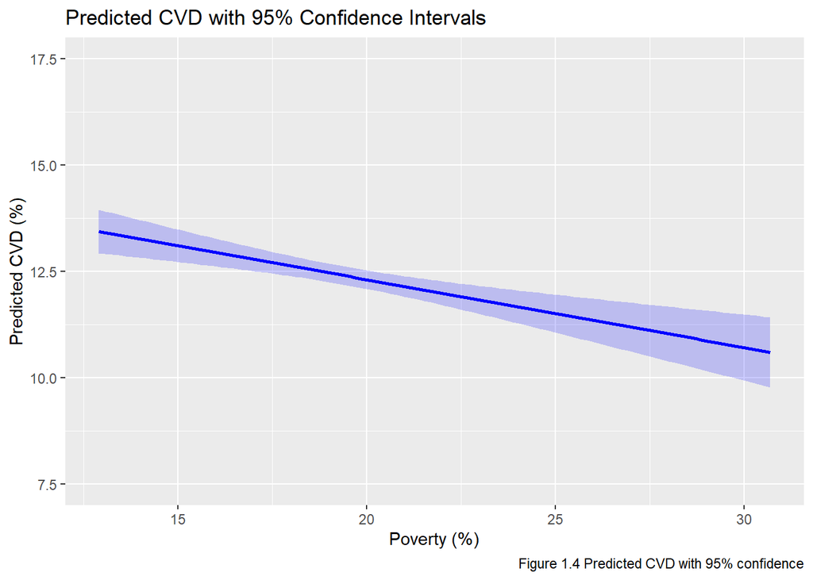

```r
# Predictions with 95% confidence intervals
predictions <- predict(m.cvd.pov.ow.int.all, predict2, interval = "confidence", level = 0.95)
predict2$fit <- predictions[, "fit"]
predict2$lwr <- predictions[, "lwr"]
predict2$upr <- predictions[, "upr"]


# Plot with confidence intervals
ggplot(predict2, aes(x = Poverty, y = fit)) +
  geom_line(size = 1, color = "blue") + #line graph for fit result
  geom_ribbon(aes(ymin = lwr, ymax = upr), alpha = 0.2, fill = "blue") + #ribbon graph for lower and upper CI
  labs(
    title = "Predicted CVD with 95% Confidence Intervals",
    x = "Poverty (%)",
    y = "Predicted CVD (%)",
    caption = "Figure 1.4 Predicted CVD with 95% confidence"
  )+
  ylim(7.5,17.5)
```

Figure 1.4 shows that an increase in the percentage of poverty has a negative impact on CVD, meaning that as the percentage of poverty in the area rises, the prevalence of CVD decreases. However, the model shows a statistically significant interaction between poverty and overweight, meaning that the percentage of overweight individuals in the area affects how the percentage of poverty influences CVD prevalence.This interaction is illustrated in the figure below.

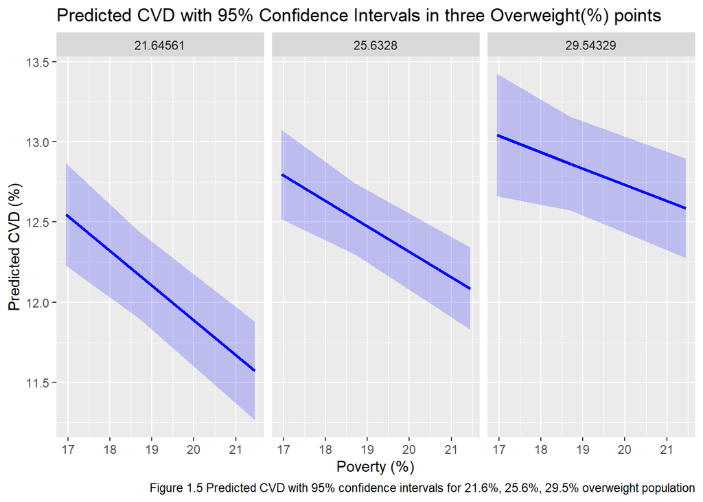

```r
# Creating a new tibble with 3 point of overweight, 3 point of poverty, and mean values of smokers and wellbeing
predict3 <-tibble (overweight=rep(c((quantile(cvdpred$overweight, 0.25)),(median(cvdpred$overweight, na.rm = TRUE)),(quantile(cvdpred$overweight, 0.75))),3),
                   Poverty=c(rep(quantile(cvdpred$Poverty,0.25),3), rep(quantile(cvdpred$Poverty,0.50),3), rep(quantile(cvdpred$Poverty,0.75),3)),
                   smokers=c(rep(mean(cvdpred$smokers, na.rm = TRUE),9)),
                   wellbeing= c(rep(mean(cvdpred$wellbeing, na.rm = TRUE),9))
                   )

predictions3 <- predict(m.cvd.pov.ow.int.all, predict3, interval = "confidence", level = 0.95)
predict3$fit <- predictions3[, "fit"]
predict3$lwr <- predictions3[, "lwr"]
predict3$upr <- predictions3[, "upr"]

ggplot(predict3, aes(x = Poverty, y = fit)) +
  geom_line(size = 1, color = "blue") + # line for fit value
  geom_ribbon(aes(ymin = lwr, ymax = upr), alpha = 0.2, fill = "blue") + # ribbon to show the upper and lower CI
  labs(
    title = "Predicted CVD with 95% Confidence Intervals in three Overweight(%) points",
    x = "Poverty (%)",
    y = "Predicted CVD (%)",
    caption = "Figure 1.5 Predicted CVD with 95% confidence intervals for 21.6%, 25.6%, 29.5% overweight population"
  )+
  facet_grid(.~overweight)
```

Figure 1.5 shows the effect of the population percentage of poverty on CVD prevalence at 21.6%, 25.6%, and 29.5%, corresponding to the values of quantile 1, the median, and quantile 3 of overweight percentage, while keeping other predictors as the mean. As the percentage of overweight individuals increases, the negative effect of poverty percentage on CVD prevalence becomes weaker.

## Conclusion

The percentage of overweight individuals, smokers, and wellbeing scores in an area are associated with higher prevalence of CVD, meaning that higher percentages of overweight individuals, smokers, and wellbeing scores correspond to an increased occurrence of CVD. However, the percentage of poverty in an area is associated with lower prevalence of CVD. The interaction between overweight and poverty is statistically significant, with areas having a higher percentage of overweight showing a weaker association between poverty and CVD prevalence, as shown in Figure 1.5.

# Question 2

## Introduction

Section 2 will evaluate how delivery time impacts customer satisfaction and how socio-economic status (SES) influences this relationship. First, the data will be explored and evaluated, followed by modeling customer satisfaction. Findings suggest that increased delivery time negatively affects customer satisfaction. Additionally, while the impact of delivery time on customer satisfaction does not differ significantly between high and medium SES categories, there is a statistically significant difference in the impact of delivery time between high and low SES categories.

```r
cust <- read_csv("cust_satisfaction.csv")
```

## Data dictionary

| Variable | Description |
| --- | --- |
| SES_category | The company’s categorisation of store type by local socio-economic-status |
| customer.satisfaction | Average customer satisfaction score |
| staff.satisfaction | Average staff job satisfaction score |
| delivery.time | The average delivery time of large and custom items |
| new_range | Whether the store was carrying a new range of products |

## Data exploration and preparation

### Distribution of data

Before the analysis is carried out, the distribution of the data is evaluated.

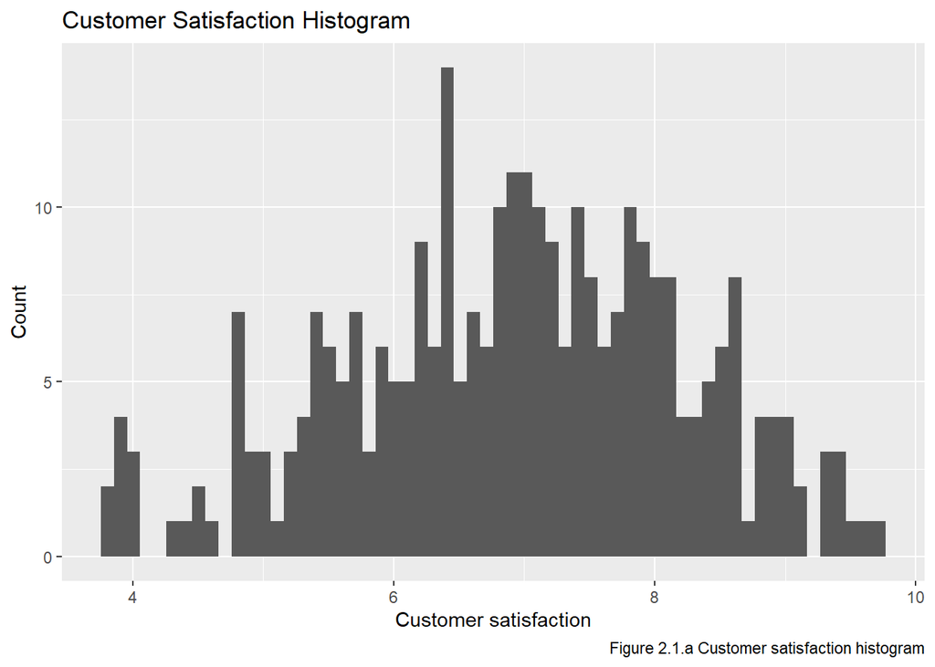

```r
cust$SES_category <-factor (cust$SES_category, levels=c("High","Medium","Low"))
ggplot(data = cust, aes(x=customer.satisfaction))+
  geom_histogram(bins = 60)+
  labs(
    title = "Customer Satisfaction Histogram",
    x = "Customer satisfaction",
    y = "Count",
    caption = "Figure 2.1.a Customer satisfaction histogram"
  )
```

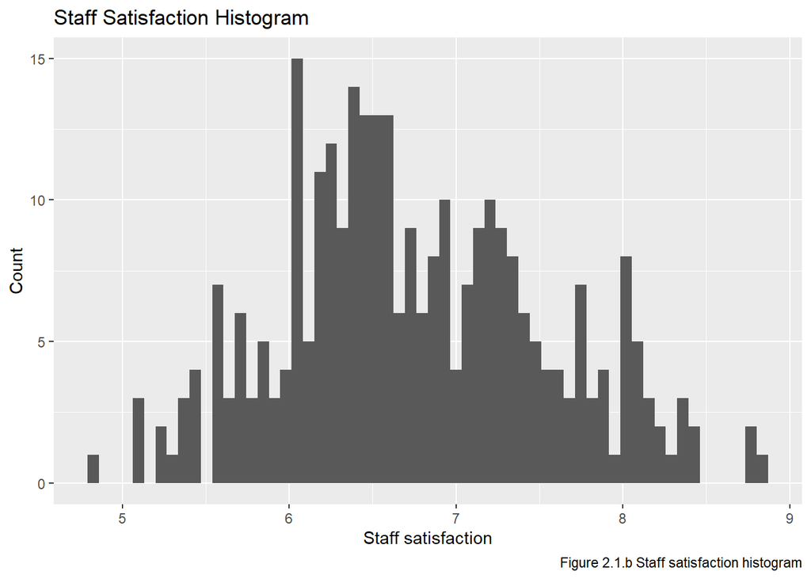

```r
ggplot(data = cust, aes(x=staff.satisfaction))+
  geom_histogram(bins = 60)+
  labs(
    title = "Staff Satisfaction Histogram",
    x = "Staff satisfaction",
    y = "Count",
    caption = "Figure 2.1.b Staff satisfaction histogram"
  )
```

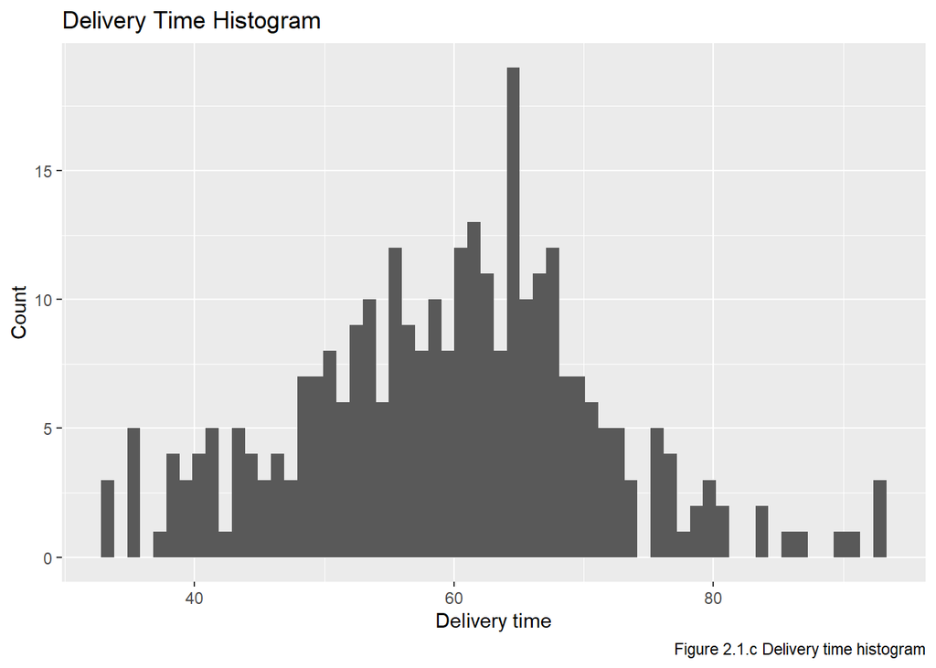

```r
ggplot(data = cust, aes(x=delivery.time))+
    geom_histogram(bins = 60)+
  labs(
    title = "Delivery Time Histogram",
    x = "Delivery time",
    y = "Count",
    caption = "Figure 2.1.c Delivery time histogram"
  )
```

Figure 2.1 shows that the distribution of customer satisfaction, staff satisfaction, and delivery time data is approximately normally distributed.

```r
SES_count <- cust %>%
  count (SES_category)
SES_count %>% kable(format="pipe")
```

| SES_category | n |
| --- | --- |
| High | 100 |
| Medium | 100 |
| Low | 100 |

Table above shows that there is an even spread on the data with 100 data for each SES_category.

```r
new_count <- cust %>%
  count (new_range)
new_count %>% kable(format = "pipe")
```

| new_range | n |
| --- | --- |
| FALSE | 142 |
| TRUE | 158 |

Table above shows that there is a small difference of 16 between stores with new category and without new category.